# **Home Advantage in the 2023 NFL Season**

Zoe Murphy and Allison Wu

Link to Website: https://awu3t.github.io/

Link to Data Set One: https://www.pro-football-reference.com/years/2023/games.htm

Link to Data Set Two: https://www.pro-football-reference.com/years/2023/attendance.htm

## **Project Plan**

This will be an investigation into NFL data from 2023. We will be looking at home wins, home team attendance, learn about what percent of each NFL stadium was filled, and other data sets relating to last season. This will allow us to determine if there is a certain stadium that has an advantage to play at.

Questions we wil look at include 'How impactful is the home-field advtantage?' 'Is there a good/bad stadium to play in' and other questions that may come up while looking into the data sets.

## **Collaboration Plan**

Our team will be meeting together once a week in person. During these meetings, we will look for datasets, discuss what information to use from tables, create visualizations, and make predictions for the project. Additionally, we will communicate via text messages in case any issues come up when we are working on individually outside of our meeting.

## **Housekeeping**

```python
import pandas as pd
```

## **Data Set One: Each NFL Football Game for 2023**

This data set comes from Pro-Football-Reference.com. This site collects data from each NFL season and makes tables out of it for people to use. With this table, the unit of observation is an NFL game from the 2023 season. This data set shows each game starting from week 1 all the way to the SuperBowl. It specifies the winner, loser, when the game was, and specifics with the points and yards. Through some data transformations, we can find out how often home teams won. Combining this table with other data sets could bring interesting information, especially with seeing what can influence a home team advantage.

```python
schedule_data = pd.read_html("https://www.pro-football-reference.com/years/2023/games.htm#games") # Reads entire table in as a list
schedule_data = schedule_data[0] # Takes the first part of list (so the entire table)
schedule_data
```

|  | Week | Day | Date | Time | Winner/tie | Unnamed: 5 | Loser/tie | Unnamed: 7 | PtsW | PtsL | YdsW | TOW | YdsL | TOL |
| --- | --- | --- | --- | --- | --- | --- | --- | --- | --- | --- | --- | --- | --- | --- |
| 0 | 1 | Thu | 2023-09-07 | 8:20PM | Detroit Lions | @ | Kansas City Chiefs | boxscore | 21 | 20 | 368 | 1 | 316 | 1 |
| 1 | 1 | Sun | 2023-09-10 | 1:00PM | Atlanta Falcons | NaN | Carolina Panthers | boxscore | 24 | 10 | 221 | 0 | 281 | 3 |
| 2 | 1 | Sun | 2023-09-10 | 1:00PM | Cleveland Browns | NaN | Cincinnati Bengals | boxscore | 24 | 3 | 350 | 2 | 142 | 0 |
| 3 | 1 | Sun | 2023-09-10 | 1:00PM | Jacksonville Jaguars | @ | Indianapolis Colts | boxscore | 31 | 21 | 342 | 2 | 280 | 3 |
| 4 | 1 | Sun | 2023-09-10 | 1:00PM | Washington Commanders | NaN | Arizona Cardinals | boxscore | 20 | 16 | 248 | 3 | 210 | 2 |
| ... | ... | ... | ... | ... | ... | ... | ... | ... | ... | ... | ... | ... | ... | ... |
| 298 | Division | Sun | 2024-01-21 | 3:00PM | Detroit Lions | NaN | Tampa Bay Buccaneers | boxscore | 31 | 23 | 391 | 0 | 408 | 2 |
| 299 | Division | Sun | 2024-01-21 | 6:30PM | Kansas City Chiefs | @ | Buffalo Bills | boxscore | 27 | 24 | 361 | 1 | 368 | 0 |
| 300 | ConfChamp | Sun | 2024-01-28 | 3:00PM | Kansas City Chiefs | @ | Baltimore Ravens | boxscore | 17 | 10 | 319 | 0 | 336 | 3 |
| 301 | ConfChamp | Sun | 2024-01-28 | 6:30PM | San Francisco 49ers | NaN | Detroit Lions | boxscore | 34 | 31 | 413 | 1 | 442 | 1 |
| 302 | SuperBowl | Sun | 2024-02-11 | 6:30PM | Kansas City Chiefs | N | San Francisco 49ers | boxscore | 25 | 22 | 455 | 2 | 382 | 2 |

303 rows × 14 columns

We really only want the columns with the game week, winner, loser, and if it was a home or away game. So, we can just drop those extra columns.

The column titled "Unnamed: 5" shows if it that respective game was a home or away game. We need to rename it so that that's more clear. Additionally, the data in that column is either "@" or NaN, but we want to change them to "Away" or "Home."

```python
# Changes to Columns and their Values

schedule_data.drop(["Day", "Date", "Time", "Unnamed: 7", "PtsW", "PtsL", "YdsW", "TOW", "YdsL", "TOL"], axis=1, inplace=True)
schedule_data.rename(columns={"Unnamed: 5": "Winner: Home or Away Game"}, inplace=True)
schedule_data["Winner: Home or Away Game"] = schedule_data["Winner: Home or Away Game"].map({"@": "Away"}).fillna("Home")
```

We also want to get rid of certain values, like playoff games. Playoff games could be considered outliers, as they're very different than regular season games. Both teams have a lot more on the line! Since this list goes in order, we can just remove the last rows related to playoffs.

Also, every 17 rows, there's a blank row with NaN values and the team is listed as "Winner/tie." We want to remove those rows so that they don't affect any of our calculations.

```python
# Deleting Specified Rows

schedule_data.dropna(subset=["Winner/tie"], inplace=True) # Drop rows with NaN
rows_without_team = schedule_data[schedule_data["Winner/tie"].str.contains("Winner/tie")].index # Specifies rows with "Winner/tie" should be dropped
schedule_data.drop(rows_without_team, axis=0, inplace=True) # Drop those rows
schedule_data.drop(schedule_data.index[-14:], axis=0, inplace=True) # Drop Playoff Games
schedule_data
```

|  | Week | Winner/tie | Winner: Home or Away Game | Loser/tie |
| --- | --- | --- | --- | --- |
| 0 | 1 | Detroit Lions | Away | Kansas City Chiefs |
| 1 | 1 | Atlanta Falcons | Home | Carolina Panthers |
| 2 | 1 | Cleveland Browns | Home | Cincinnati Bengals |
| 3 | 1 | Jacksonville Jaguars | Away | Indianapolis Colts |
| 4 | 1 | Washington Commanders | Home | Arizona Cardinals |
| ... | ... | ... | ... | ... |
| 283 | 18 | Dallas Cowboys | Away | Washington Commanders |
| 284 | 18 | Las Vegas Raiders | Home | Denver Broncos |
| 285 | 18 | Kansas City Chiefs | Away | Los Angeles Chargers |
| 286 | 18 | New York Giants | Home | Philadelphia Eagles |
| 287 | 18 | Los Angeles Rams | Away | San Francisco 49ers |

271 rows × 4 columns

Now, we should make sure our values are being interpreted correctly.

```python
schedule_data.dtypes
```

|  | 0 |
| --- | --- |
| Week | object |
| Winner/tie | object |
| Winner: Home or Away Game | object |
| Loser/tie | object |

**dtype:** object

With the table more organized, we can make a visualization of some of the data. Something interesting to look at is just the outright number of wins at home vs. away for the season. This table shows us that there is a decent advantage to playing at home. However, later in this project we will compare other factors that can influence the chances of winning, like game attendance and the type of field.

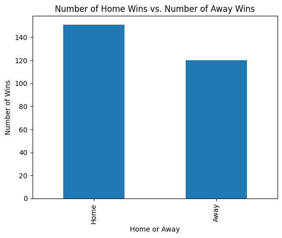

```python
home_away_count = schedule_data["Winner: Home or Away Game"].value_counts() # Gets the count of home/away wins
home_away_count.plot.bar(xlabel="Home or Away", ylabel="Number of Wins", title= "Number of Home Wins vs. Number of Away Wins") # Plots the count
```

Now, we want a column that will tell us exactly who the home team was instead of having to read three different columns to figure out who was at home. We will create a new column called "Home Team" and use if/else logic. We want to determine the home team for each row/unit of observation. Therefore, we will check the column "Winner: Home or Away Game," row by row. If the value is "Away," then we will put the value from the "Loser/tie" column into the new column. If the value is "Home," then we will put the value from the "Winner/tie" column into the new column. It will do this for every single row. This data wil come in handy when we're combining the table with other data sets.

```python
# Create new column and apply the if/else logic to each value
schedule_data["Home Team"] = schedule_data.apply(
    lambda row: row["Loser/tie"] if row["Winner: Home or Away Game"] == "Away" else row["Winner/tie"], axis=1
)

schedule_data
```

|  | Week | Winner/tie | Winner: Home or Away Game | Loser/tie | Home Team |
| --- | --- | --- | --- | --- | --- |
| 0 | 1 | Detroit Lions | Away | Kansas City Chiefs | Kansas City Chiefs |
| 1 | 1 | Atlanta Falcons | Home | Carolina Panthers | Atlanta Falcons |
| 2 | 1 | Cleveland Browns | Home | Cincinnati Bengals | Cleveland Browns |
| 3 | 1 | Jacksonville Jaguars | Away | Indianapolis Colts | Indianapolis Colts |
| 4 | 1 | Washington Commanders | Home | Arizona Cardinals | Washington Commanders |
| ... | ... | ... | ... | ... | ... |
| 283 | 18 | Dallas Cowboys | Away | Washington Commanders | Washington Commanders |
| 284 | 18 | Las Vegas Raiders | Home | Denver Broncos | Las Vegas Raiders |
| 285 | 18 | Kansas City Chiefs | Away | Los Angeles Chargers | Los Angeles Chargers |
| 286 | 18 | New York Giants | Home | Philadelphia Eagles | New York Giants |
| 287 | 18 | Los Angeles Rams | Away | San Francisco 49ers | San Francisco 49ers |

271 rows × 5 columns

This table below will show us the number of home wins for each team. Similarly to the previous function, we can use if/else logic to extract important information. We will create a new column called "Home Wins." The if/else logic is checking if the "Winner/tie" column is equal to the "Home Team" column for every row. If they are equal, "Home Wins" is 1, and if not, then it'll be 0.

Then, we can group the data by the "Winner/tie" column and sum up the home wins for each team.

The data is showing that the Cleveland Browns and the Cowboys seem to have the most home wins in the 2023 season. It will be useful to look at this in comparison to the attendance numbers with the other teams to see if the fans might have had an impact on their performance. Do AT&T Stadium (Cowboys) and Huntington Bank Field (Browns) provide an automatic advantage?

```python
# Create new column and apply if/else logic
schedule_data["Home Wins"] =schedule_data.apply(
    lambda row: 1 if row["Winner/tie"] == row["Home Team"] else 0, axis=1
)

# New df grouped by winning team. Sums up the teams home wins
Grouped_home_team_wins = schedule_data.groupby("Winner/tie")["Home Wins"].sum()

# Sorts from most home wins to least
Grouped_home_team_wins.sort_values(ascending=False)
```

| Winner/tie | Home Wins |
| --- | --- |
| Cleveland Browns | 8 |
| Dallas Cowboys | 8 |
| Miami Dolphins | 7 |
| Buffalo Bills | 7 |
| Las Vegas Raiders | 6 |
| Houston Texans | 6 |
| Detroit Lions | 6 |
| Philadelphia Eagles | 6 |
| Cincinnati Bengals | 6 |
| Baltimore Ravens | 6 |
| Chicago Bears | 5 |
| Green Bay Packers | 5 |
| Tennessee Titans | 5 |
| Pittsburgh Steelers | 5 |
| Kansas City Chiefs | 5 |
| Atlanta Falcons | 5 |
| Denver Broncos | 5 |
| Los Angeles Rams | 5 |
| Seattle Seahawks | 5 |
| San Francisco 49ers | 5 |
| New Orleans Saints | 5 |
| New York Giants | 4 |
| New York Jets | 4 |
| Tampa Bay Buccaneers | 4 |
| Jacksonville Jaguars | 4 |
| Indianapolis Colts | 4 |
| Arizona Cardinals | 2 |
| Minnesota Vikings | 2 |
| Los Angeles Chargers | 2 |
| Carolina Panthers | 2 |
| New England Patriots | 1 |
| Washington Commanders | 1 |

**dtype:** int64

## **Data Set Two: NFL Team Attendance by Week**

This data set, also from Pro-Football-Reference.com, goes over each teams attendance by week. We can see which teams had the greatest total home attendance. This does not include playoff games, it is only the regular season.

This set does not specify if they had a home or away game week by week, so we can use the data from the first set to connect that together. By doing that, we can figure out the home attendance for each game.

It will be useful to connect this data with the capacity of each NFL stadium. Then, we can see the percentage of how full each NFL stadium was.

```python
attendance_data = pd.read_html("https://www.pro-football-reference.com/years/2023/attendance.htm#attendance") # Reads entire table in as a list
attendance_data = attendance_data[0] # Takes the first part of list (so the entire table)
attendance_data
```

|  | Tm | Total | Home | Away | Week 1 | Week 2 | Week 3 | Week 4 | Week 5 | Week 6 | ... | Week 9 | Week 10 | Week 11 | Week 12 | Week 13 | Week 14 | Week 15 | Week 16 | Week 17 | Week 18 |
| --- | --- | --- | --- | --- | --- | --- | --- | --- | --- | --- | --- | --- | --- | --- | --- | --- | --- | --- | --- | --- | --- |
| 0 | Arizona Cardinals | 1113568 | 502912.0 | 610656.0 | 64693 | 62080 | 62915 | 71521 | 62651 | 71202 | ... | 67919 | 62861 | 70247 | 62177 | 66436 | Bye | 63967 | 59978 | 69879 | 63197 |
| 1 | Atlanta Falcons | 1176416 | 556828.0 | 619588.0 | 69597 | 69251 | 63803 | 85716 | 69461 | 69921 | ... | 69715 | 62861 | Bye | 70166 | 74455 | 69496 | 70301 | 69221 | 61752 | 70072 |
| 2 | Baltimore Ravens | 1170734 | 635380.0 | 535354.0 | 70136 | 66015 | 70038 | 67919 | 67272 | 61011 | ... | 70753 | 70424 | 70997 | 70240 | Bye | 70492 | 68021 | 71812 | 71196 | 70355 |
| 3 | Buffalo Bills | 1183200 | 626483.0 | 556717.0 | 83345 | 70772 | 64291 | 70881 | 61273 | 70515 | ... | 66965 | 70318 | 70603 | 69879 | Bye | 73639 | 70933 | 67678 | 70772 | 66292 |
| 4 | Carolina Panthers | 1163926 | 573086.0 | 590840.0 | 69597 | 72709 | 68699 | 72842 | 63648 | 65529 | ... | 72301 | 61200 | 73543 | 62493 | 62432 | 70009 | 70301 | 70875 | 67233 | 69010 |
| 5 | Chicago Bears | 1111491 | 494157.0 | 617334.0 | 62456 | 62976 | 73562 | 62220 | 63727 | 62167 | ... | 70006 | 61200 | 63873 | 66843 | Bye | 62185 | 67919 | 59978 | 61752 | 78188 |
| 6 | Cincinnati Bengals | 1144696 | 594361.0 | 550335.0 | 67919 | 66015 | 65158 | 68951 | 62651 | 66385 | ... | 66965 | 66526 | 70997 | 65090 | 67951 | 65981 | 66376 | 66646 | 73565 | 65865 |
| 7 | Cleveland Browns | 1168498 | 610295.0 | 558203.0 | 67919 | 67576 | 67919 | 67919 | Bye | 67431 | ... | 67919 | 70424 | 67919 | 76261 | 72887 | 67431 | 67919 | 70831 | 67919 | 65865 |
| 8 | Dallas Cowboys | 1378746 | 748755.0 | 629991.0 | 80809 | 93689 | 62915 | 93719 | 71617 | 70240 | ... | 69879 | 93338 | 73543 | 93711 | 93367 | 93752 | 70933 | 66410 | 93731 | 63645 |
| 9 | Denver Broncos | 1226925 | 687498.0 | 539427.0 | 76299 | 76108 | 65522 | 62220 | 76387 | 73528 | ... | Bye | 70318 | 76848 | 76261 | 71670 | 70240 | 64500 | 76201 | 76228 | 61429 |
| 10 | Detroit Lions | 1170249 | 518741.0 | 651508.0 | 73522 | 66434 | 63803 | 78052 | 63648 | 65854 | ... | Bye | 70240 | 63873 | 66476 | 70003 | 62185 | 64500 | 66932 | 93731 | 63233 |
| 11 | Green Bay Packers | 1242403 | 622636.0 | 619767.0 | 62456 | 69251 | 78043 | 78052 | 62572 | Bye | ... | 77409 | 67617 | 77432 | 66476 | 78124 | 76637 | 77275 | 70875 | 67003 | 78188 |
| 12 | Houston Texans | 1184936 | 640742.0 | 544194.0 | 70136 | 71159 | 61466 | 71399 | 69461 | 71810 | ... | 70785 | 66526 | 70247 | 71324 | 71670 | 72956 | 66219 | 70831 | 71517 | 65925 |
| 13 | Indianapolis Colts | 1113729 | 587393.0 | 526336.0 | 65749 | 71159 | 70038 | 65337 | 65287 | 64851 | ... | 72301 | 50144 | Bye | 64407 | 62641 | 65981 | 64171 | 69221 | 65538 | 65925 |
| 14 | Jacksonville Jaguars | 1150901 | 621599.0 | 529302.0 | 65749 | 69915 | 61466 | 85716 | 61273 | 64851 | ... | Bye | 69271 | 67175 | 71324 | 67951 | 67431 | 68021 | 62547 | 67233 | 63744 |
| 15 | Kansas City Chiefs | 1205847 | 638715.0 | 567132.0 | 73522 | 69915 | 73562 | 80461 | 67003 | 73528 | ... | 50023 | Bye | 73754 | 62441 | 78124 | 73639 | 64628 | 73480 | 73565 | 68274 |
| 16 | Las Vegas Raiders | 1111041 | 559713.0 | 551328.0 | 76299 | 70772 | 62541 | 70240 | 62572 | 61985 | ... | 62082 | 62383 | 66026 | 62441 | Bye | 62626 | 61654 | 73480 | 65538 | 61429 |
| 17 | Los Angeles Chargers | 1190939 | 627632.0 | 563307.0 | 70240 | 67438 | 66878 | 70240 | Bye | 70240 | ... | 75407 | 70240 | 77432 | 70240 | 64628 | 70240 | 61654 | 67678 | 76228 | 68274 |
| 18 | Los Angeles Rams | 1235049 | 585204.0 | 649845.0 | 68683 | 74742 | 65158 | 65337 | 74935 | 71202 | ... | 77409 | Bye | 72704 | 62177 | 72887 | 70492 | 72035 | 73228 | 75517 | 71624 |
| 19 | Miami Dolphins | 1136583 | 593304.0 | 543279.0 | 70240 | 64628 | 65522 | 70881 | 65654 | 65529 | ... | 50023 | Bye | 66026 | 82973 | 63459 | 66068 | 65967 | 66410 | 71196 | 66292 |
| 20 | Minnesota Vikings | 1157107 | 535308.0 | 621799.0 | 66741 | 69879 | 66878 | 72842 | 67003 | 62167 | ... | 69715 | 66933 | 76848 | 66843 | Bye | 62626 | 66376 | 66932 | 67003 | 63233 |
| 21 | New England Patriots | 1165144 | 567168.0 | 597976.0 | 64628 | 64628 | 80876 | 93719 | 64628 | 61985 | ... | 64628 | 50144 | Bye | 82211 | 64628 | 66376 | 64628 | 76201 | 70772 | 64628 |
| 22 | New Orleans Saints | 1188849 | 560164.0 | 628685.0 | 70024 | 72709 | 78043 | 70003 | 64628 | 71810 | ... | 70006 | 66933 | Bye | 70166 | 70003 | 70009 | 70038 | 73228 | 65741 | 70072 |
| 23 | New York Giants | 1262352 | 634459.0 | 627893.0 | 80809 | 62080 | 71593 | 78507 | 65654 | 70515 | ... | 62082 | 93338 | 62714 | 82211 | Bye | 76637 | 70038 | 69879 | 75517 | 75740 |
| 24 | New York Jets | 1285954 | 701011.0 | 584943.0 | 83345 | 93689 | 80876 | 80461 | 76387 | 83068 | ... | 75407 | 62383 | 70603 | 82973 | 74455 | 72956 | 65967 | 67470 | 67919 | 64628 |
| 25 | Philadelphia Eagles | 1223746 | 559032.0 | 664714.0 | 64628 | 69879 | 65426 | 69879 | 74935 | 83068 | ... | 69879 | Bye | 73754 | 69879 | 69879 | 93752 | 68758 | 69879 | 69879 | 75740 |
| 26 | Pittsburgh Steelers | 1146477 | 602796.0 | 543681.0 | 67679 | 67576 | 62541 | 71399 | 67272 | Bye | ... | 65969 | 67617 | 67919 | 65090 | 66436 | 66376 | 64171 | 66646 | 68735 | 70355 |
| 27 | San Francisco 49ers | 1186315 | 573245.0 | 613070.0 | 67679 | 74742 | 71593 | 71521 | 71617 | 67431 | ... | Bye | 69271 | 71607 | 68702 | 69879 | 71816 | 63967 | 71812 | 64424 | 71624 |
| 28 | Seattle Seahawks | 1193230 | 549886.0 | 643344.0 | 68683 | 66434 | 68699 | 78507 | Bye | 66385 | ... | 70753 | 68721 | 72704 | 68702 | 93367 | 71816 | 68758 | 60181 | 68735 | 63197 |
| 29 | Tampa Bay Buccaneers | 1140061 | 510321.0 | 629740.0 | 66741 | 62976 | 65426 | 70003 | Bye | 65854 | ... | 70785 | 62725 | 71607 | 64407 | 62432 | 69496 | 77275 | 62547 | 65741 | 69010 |
| 30 | Tennessee Titans | 1117370 | 580686.0 | 536684.0 | 70024 | 67438 | 67919 | 68951 | 65287 | 61011 | ... | 65969 | 62725 | 67175 | 62493 | 62641 | 66068 | 66219 | 60181 | 71517 | 63744 |
| 31 | Washington Commanders | 1175750 | 511606.0 | 664144.0 | 64693 | 76108 | 64291 | 69879 | 63727 | 69921 | ... | 64628 | 68721 | 62714 | 93711 | 63459 | Bye | 72035 | 67470 | 64424 | 63645 |
| 32 | NaN | 18911116 | NaN | NaN | 1122520 | 1125371 | 1088730 | 1177647 | 936115 | 1025497 | ... | 953841 | 942701 | 985442 | 1135394 | 917932 | 1059704 | 1082762 | 1093369 | 1130750 | 1081221 |

33 rows × 22 columns

We don't need the last row which is a mix of NaN values and totals for the week.

```python
attendance_data.drop(attendance_data.index[-1], axis=0, inplace=True)
```

We can see what the data types are now since we have the desired rows/columns. Weeks 1-4, every team had a game, so attendance was taken for all of the teams. However, starting at Week 5 there were "bye" games for some teams. This means they did not play a game then, therefore no attendance was taken and the value in the column is "bye." We are not sure what type we want all of the columns to be just yet, so we're not going to make any changes to the types. We will just make a note of this.

```python
attendance_data.dtypes
```

|  | 0 |
| --- | --- |
| Tm | object |
| Total | int64 |
| Home | float64 |
| Away | float64 |
| Week 1 | int64 |
| Week 2 | int64 |
| Week 3 | int64 |
| Week 4 | int64 |
| Week 5 | object |
| Week 6 | object |
| Week 7 | object |
| Week 8 | int64 |
| Week 9 | object |
| Week 10 | object |
| Week 11 | object |
| Week 12 | int64 |
| Week 13 | object |
| Week 14 | object |
| Week 15 | int64 |
| Week 16 | int64 |
| Week 17 | int64 |
| Week 18 | int64 |

**dtype:** object

The mean and median home attendance for the teams were pretty close to each other. There shouldn't be a huge outlier in this data!

```python
attendance_data["Home"].mean()
```

```
590972.375
```

```python
attendance_data["Home"].median()
```

```
586298.5
```

Let's just look at the overall home attendance numbers. Again, these will be more useful with analysis into the stadium size.

We notice that the Dallas Cowboys had the highest overall home attendance. With the Cowboys having the most home wins and the most fans at their home games, it could be a sign that they have the best home field advantage. However, the Cleveland Browns were 12th on the list, but tied for first for home wins. This shows that we need some more analysis before we make conclusions.

```python
# Create df grouped by the team and showing the total home attendance
total_home_attendance = attendance_data.groupby("Tm")["Home"].sum()

# Sort them from highest to lowest
total_home_attendance.sort_values(ascending=False)
```

| Tm | Home |
| --- | --- |
| Dallas Cowboys | 748755.0 |
| New York Jets | 701011.0 |
| Denver Broncos | 687498.0 |
| Houston Texans | 640742.0 |
| Kansas City Chiefs | 638715.0 |
| Baltimore Ravens | 635380.0 |
| New York Giants | 634459.0 |
| Los Angeles Chargers | 627632.0 |
| Buffalo Bills | 626483.0 |
| Green Bay Packers | 622636.0 |
| Jacksonville Jaguars | 621599.0 |
| Cleveland Browns | 610295.0 |
| Pittsburgh Steelers | 602796.0 |
| Cincinnati Bengals | 594361.0 |
| Miami Dolphins | 593304.0 |
| Indianapolis Colts | 587393.0 |
| Los Angeles Rams | 585204.0 |
| Tennessee Titans | 580686.0 |
| San Francisco 49ers | 573245.0 |
| Carolina Panthers | 573086.0 |
| New England Patriots | 567168.0 |
| New Orleans Saints | 560164.0 |
| Las Vegas Raiders | 559713.0 |
| Philadelphia Eagles | 559032.0 |
| Atlanta Falcons | 556828.0 |
| Seattle Seahawks | 549886.0 |
| Minnesota Vikings | 535308.0 |
| Detroit Lions | 518741.0 |
| Washington Commanders | 511606.0 |
| Tampa Bay Buccaneers | 510321.0 |
| Arizona Cardinals | 502912.0 |
| Chicago Bears | 494157.0 |

**dtype:** float64